# Introdução histórica

Historicamente falando a FFT tem sua peculiaridade,começando em 1805 quando Gauss tentou traçar a órbita de dois asteroides, Pallas e Juno.Assim ele desenvolveu a transformada discreta de Fourier (DFT), antes mesmo que Fourier publicasse os seu resultados em 1822, para que pudesse ser calculado a DFT, Gaus, inventou um algoritmo que é equivalente ao de Cooley e Tukey, criadores da FFT. Em 1965 J.W. Cooley e J.W. Tukey motivados pelo período de guerra que os EUA viva, interessados em descobrir um método para detectar testes nucleares soviéticos, desenvolveram um algorítimo que calculava a DFT da sequência de n números com mais eficiência, conseguindo usar seu algoritmo para detectar séries temporais sismológicas e conseguindo detectar os testes nucleares.

# Transformada de Fourier

A motivação para a transformada de Fourier veio com o estudo da série de Fourier. No estudo da série de Fourier, funções que são complicadas mas periódicas podem ser escritas através da soma de senos e cossenos. Devido as propriedades que o seno e o cosseno possuem é possível recuperar a amplitude de cada onda na série de Fourier. Muito dos casos é aconselhável usar a forma de Euler, $$e^{(2 \pi i \theta)} = \cos(2 \pi \theta) + i \sin(2 \pi \theta)$$ Re-escrever senos e cossenos como exponenciais complexas faz-se necessário que o coeficiente de Fourier seja de valores complexos, a interpolação destes números complexos é que tanto a amplitude(ou tamanho) como a fase (ou ângulo inicial) estão presentes na onda.

[figure not shown]

caso a imagem não apareça, acesse o [link](https://upload.wikimedia.org/wikipedia/commons/7/72/Fourier_transform_time_and_frequency_domains_%28small%29.gif)

No primeiro frame da animação, a função $\textit{f}$ é solucionada usando a série de Fourier : combinação linear de senos e cossenos (azul).A frequência que compões esses senos e cossenos que estão espalhados por todo o espectro de frequência, são representados como picos no domínio da frequência. A representação do domínio da frequência da função $\hat{f}$, é construído baseado nos picos das frequências que aparecem na resolução da função.

# Teste da transformada rápida de Fourier (FFT)

Nessa parte do trabalho iremos testar como o cálculo da FFT irá se comportar com as bibliotecas **Numpy** e **Scipy**

$$y[k]=\sum\limits_{n=0}^{\mbox{N-1}} W_n x[n]$$ $$W_n = e^{-2 \pi j\frac{km}{N}}$$

Iremos calcular a FFT de um vetor com 4096 valores aleatórios usando as bibliotecas propostas e assim iremos analisar o tempo de compilação de cada.

```python
#Definindo as Bibliotecas que iremos usar
import cmath as mt
from tabulate import tabulate
import time
import scipy as sc  #criando um objeto sc da classe scipy
import numpy as nm  #criando um objeto nm da classe numpy
import matplotlib.pyplot as plt #criando um objeto plt da classe matplotlib.pyplot
%matplotlib inline
import random
import warnings
warnings.filterwarnings('ignore')
```

```python
#-----------------Definindo quais serão os 4096 números------------------

N = 4096 #tendo 4096 amostras
x=[[int(1000*random.random()) for i in range(N)]]  #Gerando 4096 amostras com N variando de 0-1000


#-----------------Usando o Scipy para FFT------------------

start_time = time.time()
y=sc.fft(x)
timeScipy=(time.time() - start_time)
print("Para o Scipy teremos o tempo de %s segundos ---" % timeScipy)

#-----------------Usando o Numpy para FFT------------------

start_time = time.time()
y1=nm.fft.fft(x)
timeNumpy=(time.time() - start_time)
print("Para o NUmpy teremos o tempo de %s segundos ---" % timeNumpy)
```

```
Para o Scipy teremos o tempo de 0.0009989738464355469 segundos ---
Para o NUmpy teremos o tempo de 0.0015017986297607422 segundos ---
```

```python
start_time = time.time()
N=4096
y=0
x=[]
# Definindo o valores aleatórios do vetor X
for i in range(N):
    x.append(int(1000*random.random()))
# Implementação da FFT
for i in range(N):
    z=mt.cos(2*mt.pi*x[i]*y/N)-1j*mt.sin(2*mt.pi*x[i]*y/N)
    x[i]=z
    y=y+1
timeMyFFt=(time.time() - start_time)
print("Para a código de FFT que desenvolvemos teremos o tempo de %s segundos ---" % timeMyFFt)
```

```
Para a código de FFT que desenvolvemos teremos o tempo de 0.018512248992919922 segundos ---
```

# Teste da transformada rápida de Fourier inversa (IFFT)

Nessa parte do trabalho iremos testar como o cálculo da IFFT irá se comportar com as bibliotecas **Numpy** e **Scipy**

$$x[n]=\frac{1}{N} \times \sum\limits_{n=0}^{\mbox{N-1}} W_n y[k]$$ $$W_n = e^{2 \pi j\frac{km}{N}}$$

Iremos calcular a FFT de um vetor com 4096 valores aleatórios usando as bibliotecas propostas e assim iremos analisar o tempo de compilação de cada.

```python
#-----------------Definindo quais serão os 4046 números------------------

N = 4096 #tendo 4046 amostras
x=[[int(1000*random.random()) for i in range(N)]]  #Gerando 4046 amostras com N variando de 0-1000


#-----------------Usando o Scipy para IFFT------------------

start_time = time.time()
y=sc.ifft(x)
timeScipy2=(time.time() - start_time)
print("Para o Scipy teremos o tempo de %s segundos ---" % timeScipy2)

#-----------------Usando o Numpy para IFFT------------------

start_time = time.time()
y1=nm.fft.ifft(x)
timeNumpy2=(time.time() - start_time)
print("Para o NUmpy teremos o tempo de %s segundos ---" % timeNumpy2)
```

```
Para o Scipy teremos o tempo de 0.0009999275207519531 segundos ---
Para o NUmpy teremos o tempo de 0.0010097026824951172 segundos ---
```

```python
start_time = time.time()
N=4096
y=0
x=[]
# Definindo o valores aleatórios do vetor X
for i in range(N):
    x.append(int(1000*random.random()))
# Implementação da IFFT
for i in range(N):
    z=1/N*mt.cos(2*mt.pi*x[i]*y/N)+1j*mt.sin(2*mt.pi*x[i]*y/N)
    x[i]=z
    y=y+1
timeMyIFFt=(time.time() - start_time)
print("Para a código de IFFT que desenvolvemos teremos o tempo de %s segundos ---" % timeMyIFFt)
```

```
Para a código de IFFT que desenvolvemos teremos o tempo de 0.017501354217529297 segundos ---
```

# Exemplo

Para poder exemplificar o uso da FFT e da IFFT de uma forma ainda mais clara, iremos utilizar a soma de dois cossenos,onde:

Teremos $N=4096$ amostras aleatórias e um período de $T=\frac{1}{800}$, assim poderemos testar como o **Scipy** e o **Numpy** irão trabalhar com a parte matemática e gráfica do resultado. Lembrando que anteriormente testamos as duas bibliotecas para calcular a FFT e a IFFT de um vetor com 4096 valores aleatórios.

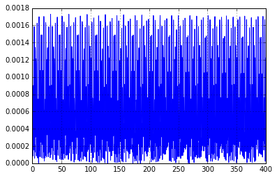

```python
N = 4096
T = 1.0 /800.0
x = nm.linspace(0.0, N*T, N)
y = 2*nm.cos(5*nm.pi*(30*x) ) + 1.54*nm.cos(2*nm.pi*(20*x) )

xf = nm.linspace(0.0, 1.0/(2.0*T), N/2)
plt.plot(xf, 2.0/N * nm.abs(y[0:N/2]))
plt.grid()
plt.show()
```

## Usando FFT

#### Resolução do exemplo usando scipy

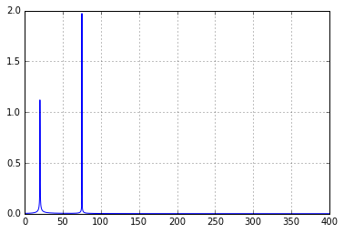

```
Tempo de compilação para a biblioteca Numpy é de 0.1675586700439453 segundos ---
```

```python
start_time = time.time()
N = 4096
T = 1.0 / 800.0
x = sc.linspace(0.0, N*T, N)
y = 2*nm.cos(5*nm.pi*(30*x) ) + 1.54*nm.cos(2*nm.pi*(20*x) )
yf = sc.fft(y)
xf = sc.linspace(0.0, 1.0/(2.0*T), N/2)


plt.plot(xf, 2.0/N * nm.abs(yf[0:N/2]))
plt.grid()
plt.show()
timePlotScipyFft=time.time() - start_time
print("Tempo de compilação para a biblioteca Numpy é de %s segundos ---" % timePlotScipyFft)
```

#### Resolução do exemplo usando numpy

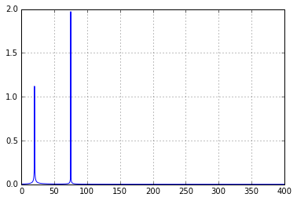

```
Tempo de compilação para a biblioteca Numpy é de 0.1608266830444336 segundos ---
```

```python
start_time = time.time()
N = 4096
T = 1.0 / 800.0
x = nm.linspace(0.0, N*T, N)
y = 2*nm.cos(5*nm.pi*(30*x) ) + 1.54*nm.cos(2*nm.pi*(20*x) )
yf = nm.fft.fft(y)
xf = nm.linspace(0.0, 1.0/(2.0*T), N/2)


plt.plot(xf, 2.0/N * nm.abs(yf[0:N/2]))
plt.grid()
plt.show()
timePlotNumpyFft=time.time() - start_time
print("Tempo de compilação para a biblioteca Numpy é de %s segundos ---" % timePlotNumpyFft)
```

## Usando IFFT

#### Resolução do exemplo usando scipy

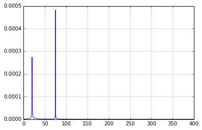

```
Tempo de compilação para a biblioteca Scipy é de 0.17268681526184082 segundos ---
```

```python
start_time = time.time()
N = 4096
T = 1.0 / 800.0
x = sc.linspace(0.0, N*T, N)
y = 2*nm.cos(5*nm.pi*(30*x) ) + 1.54*nm.cos(2*nm.pi*(20*x) )
yf = sc.ifft(y)
xf = sc.linspace(0.0, 1.0/(2.0*T), N/2)


plt.plot(xf, 2.0/N * nm.abs(yf[0:N/2]))
plt.grid()
plt.show()
timePlotScipyIfft= time.time() - start_time
print("Tempo de compilação para a biblioteca Scipy é de %s segundos ---" % timePlotScipyIfft)
```

#### Resolução do exemplo usando numpy

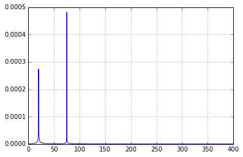

```
Tempo de compilação para a biblioteca Numpy é de 0.1755847930908203 segundos ---
```

```python
start_time = time.time()
N = 4096
T = 1.0 / 800.0
x = nm.linspace(0.0, N*T, N)
y = 2*nm.cos(5*nm.pi*(30*x) ) + 1.54*nm.cos(2*nm.pi*(20*x) )
yf = nm.fft.ifft(y)
xf = nm.linspace(0.0, 1.0/(2.0*T), N/2)


plt.plot(xf, 2.0/N * nm.abs(yf[0:N/2]))
plt.grid()
plt.show()
timePlotNumpyIfft= time.time() - start_time
print("Tempo de compilação para a biblioteca Numpy é de %s segundos ---" % timePlotNumpyIfft)
```

# Conclusão

Para o teste com o vetor de 4096 valores aleatórios temos o gráfico abaixo

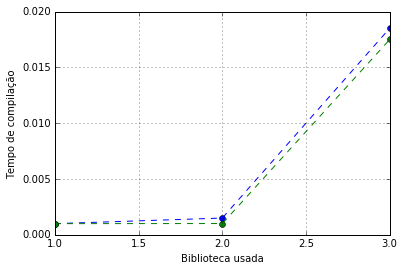

```python
k=[1,2,3]
c=[timeScipy,timeNumpy,timeMyFFt]
b=[timeScipy2,timeNumpy2,timeMyIFFt]
plt.grid()
plt.xlabel('Biblioteca usada')
plt.ylabel('Tempo de compilação')
plt.plot(k,c,'--o',k,b,'--o')
```

```python
table = [["Scipy - FFT",timeScipy],["Numpy - FFT",timeNumpy],["MyFFt",timeMyFFt],["Scipy - IFFT",timeScipy2],
         ["Numpy - IFFT",timeNumpy2],["MyIFFT",timeMyIFFt]]
headers = ["Biblioteca usada", "Tempo de compilação (segundos)"]
print(tabulate(table, headers, tablefmt="grid"))
```

```
+--------------------+----------------------------------+
| Biblioteca usada   |   Tempo de compilação (segundos) |
+====================+==================================+
| Scipy - FFT        |                      0.000998974 |
+--------------------+----------------------------------+
| Numpy - FFT        |                      0.0015018   |
+--------------------+----------------------------------+
| MyFFt              |                      0.0185122   |
+--------------------+----------------------------------+
| Scipy - IFFT       |                      0.000999928 |
+--------------------+----------------------------------+
| Numpy - IFFT       |                      0.0010097   |
+--------------------+----------------------------------+
| MyIFFT             |                      0.0175014   |
+--------------------+----------------------------------+
```

Tabela referente ao tempo gasto para que cada biblioteca compile o cálculo da FFT e IFFT

### Conclusão do exemplo

Agora iremos construir um gráfico para melhor vizualizarmos de como as bibliotecas se comportam com a resolução completa -cálculo matemático e construção do gráfico- da soma dos cossenos.

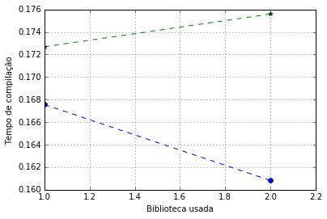

```python
k=[1,2]
c=[timePlotScipyFft,timePlotNumpyFft]
b=[timePlotScipyIfft,timePlotNumpyIfft]
plt.grid()
plt.xlabel('Biblioteca usada')
plt.ylabel('Tempo de compilação')
plt.plot(k,c,'--o',k,b,'--*')
```

Como o esperado, o tempo gasto para poder calcular a FFT tende a ser menor que o tempo gasto para calcular a IFFT

```python
table = [["Scipy - FFT",timePlotScipyFft],["Numpy - FFT",timePlotNumpyFft],
         ["Scipy - IFFT",timePlotScipyIfft],["Numpy - IFFT",timePlotNumpyIfft]]
headers = ["Biblioteca usada", "Tempo de compilação (segundos)"]
print(tabulate(table, headers, tablefmt="grid"))
```

```
+--------------------+----------------------------------+
| Biblioteca usada   |   Tempo de compilação (segundos) |
+====================+==================================+
| Scipy - FFT        |                         0.167559 |
+--------------------+----------------------------------+
| Numpy - FFT        |                         0.160827 |
+--------------------+----------------------------------+
| Scipy - IFFT       |                         0.172687 |
+--------------------+----------------------------------+
| Numpy - IFFT       |                         0.175585 |
+--------------------+----------------------------------+
```

Tabela referente ao tempo gasto para que cada biblioteca compile o cálculo e a construção do gráfico da soma dos cossenos, usando FFT e IFFT

# Referências

Taneja, HC (2008), "Chapter 18: Fourier integrals and Fourier transforms", Advanced Engineering Mathematics:, Volume 2, New Delhi, India: I. K. International Pvt Ltd, ISBN 8189866567.

www.astro.if.ufrgs.br/med/imagens/fourier.htm

www.en.wikipedia.org/wiki/Fourier_transform#CITEREFTaneja2008

www.docs.scipy.org/doc/numpy-1.10.1/index.html

www.cis.rit.edu/class/simg716/Gauss_History_FFT.pdf

www2.math.ethz.ch/education/bachelor/seminars/fs2008/nas/woerner.pdf

www.en.wikipedia.org/wiki/File:Fourier_transform_time_and_frequency_domains_(small).gif

www.pypi.python.org/pypi/tabulate

www.researchgate.net/post/Why_do_we_use_IFFT